# Clustering based on businesses strategic actions

An implementation in hierarchical clustering technique

Arogya Koirala

2021-06-03

# Why?

# Setup

Import necessary libraries.

```r
library(vegan)
library(ggplot2)
library(purrr)
library(rworldmap)
library(leaflet)
library(cluster)
library(UpSetR)
library(DT)
# Imports
source("~/projects/c2m2/kathmandu-survey/utils/functions.R")
source("~/projects/c2m2/kathmandu-survey/utils/constants.R")
```

# Data import

In this step, we import the latest business survey dataset, select relavant columns for our analysis, and rename columns for better legibility.

```r
# Get survey data
survey_data_path <- paste0(
  ROOT_URL,
  "raw/data/business_data_20210531_wloc.xlsx"
)

businesses <- IO.XlsSheetToDF(
  excel_sheets(survey_data_path)[1],
  survey_data_path
)

# Create flag variable to distinguish
# permanently closed businesses
businesses <- businesses %>%
  mutate(d_shut_down_perm = ifelse(
    (i_econ_stop_business == 3), T, F))

# Subset data to only include HHS variables
hhs_vars <- c("X_index",
  "d_shut_down_perm",
  "o_expectd_problms_next_6_mnths__1",
  "o_expectd_problms_next_6_mnths__2",
  "o_expectd_problms_next_6_mnths__3",
  "o_expectd_problms_next_6_mnths__4",
  "o_expectd_problms_next_6_mnths__5",
  "o_expectd_problms_next_6_mnths__6",
  "o_expectd_problms_next_6_mnths__7",
  "m_biz_type",
  "m_coodinates",
  "X_m_coodinates_latitude",
  "X_m_coodinates_longitude",
  "m_name_business"
)

# Rename columns
businesses_hhs <- businesses %>% select(all_of(hhs_vars))
colnames(businesses_hhs) <- c(
  "id",
  "perm_closed",
  "pay_loans",
  "get_funds",
  "pay_taxes",
  "op_cost",
  "labor",
  "get_custs",
  "none",
  "type",
  "coordinates",
  "X_m_coodinates_latitude",
  "X_m_coodinates_longitude",
  "name"
)

renamed_cols <- colnames(businesses_hhs)

businesses_hhs <- businesses_hhs %>% filter(perm_closed == F)

# Preview
knitr::kable(
  businesses_hhs[1:6, 1:6], caption = 'A subset of businesses_hhs'
)
```

A subset of businesses_hhs

| id | perm_closed | pay_loans | get_funds | pay_taxes | op_cost |
| --- | --- | --- | --- | --- | --- |
| 36 | FALSE | 1 | 1 | 1 | 1 |
| 109 | FALSE | 1 | 0 | 0 | 0 |
| 8 | FALSE | 0 | 0 | 0 | 0 |
| 69 | FALSE | 1 | 0 | 0 | 1 |
| 110 | FALSE | 1 | 1 | 1 | 1 |
| 21 | FALSE | 0 | 0 | 0 | 1 |

# Exploratory data analysis using the UpsetR package

The package `UpsetR`, which provides intersection totals for a combination of binary variables can be used to quickly scan through data.

```r
# Subset columns of interest
subs <- businesses_hhs %>% select(c(colnames(businesses_hhs)[3:11]))

# Function to convert all factors to numeric
asNumeric <- function(x) as.numeric(as.character(x))
factorsNumeric <- function(d) modifyList(
  d,
  lapply(d[, sapply(d, is.factor)],asNumeric)
)

# Visualize using UpsetR
upset(factorsNumeric(subs),
      order.by="freq",
      main.bar.color = "#c3092b",
      sets.bar.color = "#c3092b",
      group.by = "degree"
)
```

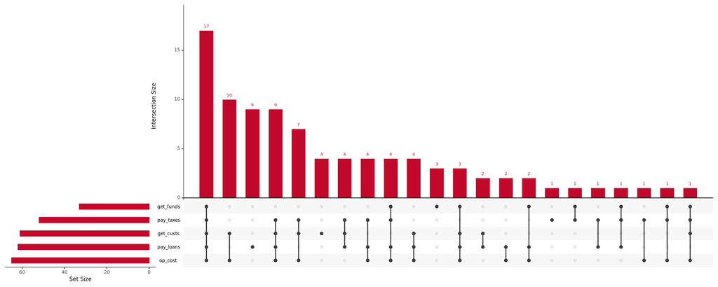

# Performing hierarchical clustering

Link 1: Approach, https://uc-r.github.io/hc_clustering

Link 2: We are going to use Jaccard distances (see, https://towardsdatascience.com/user-similarity-with-binary-data-in-python-d15940a702fc)

```r
# Subset only relevant columns
measures_var <- renamed_cols[3:9]
df <- businesses_hhs %>%
  select(all_of(measures_var))

# Convert columns to numeric values
indx <- sapply(df, is.factor)
df[indx] <- lapply(df[indx], function(x) as.numeric(as.character(x)))

# Compute distance matrix based on "jaccard" distance
dist.mat<-vegdist(
  df,
  method="jaccard",
  binary = T
)


# methods to assess
m <- c( "average", "single", "complete", "ward")
names(m) <- c( "average", "single", "complete", "ward")

# function to compute coefficient
ac <- function(x) {
  agnes(df, method = x)$ac
}

map_dbl(m, ac)
```

```
##   average    single  complete      ward
## 0.9144484 0.8885596 0.9353823 0.9780791
```

```r
# Perform and plot clustering results
clust.res<-hclust(dist.mat, method = "ward") #agglomerative clustering using complete linkage
```

```
## The "ward" method has been renamed to "ward.D"; note new "ward.D2"
```

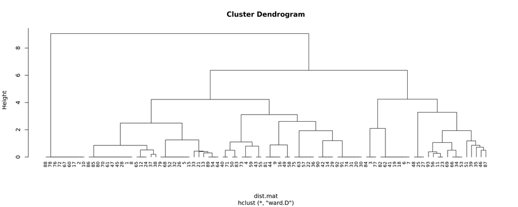

```r
plot(clust.res, hang=-1, cex=0.8)
```

## Notes:

1. We will be using k=5 to assign clusters

# Assigning clusters and profiling

Our next step is to assign cluster values to the dataset, and then generate statistics for each cluster to get a sense of cluster characteristics. Before we do that, however, lets look at percentage values for different columns for the entire population.

```r
totals <- df %>% summarise(
  n = n(),
  pay_loans=round(sum(as.numeric(as.character(pay_loans)))/n(), 2),
  get_funds=round(sum(as.numeric(as.character(get_funds)))/n(),2),
  pay_taxes=round(sum(as.numeric(as.character(pay_taxes)))/n(),2),
  op_cost=round(sum(as.numeric(as.character(op_cost)))/n(),2),
  labor=round(sum(as.numeric(as.character(labor)))/n(),2),
  get_custs=round(sum(as.numeric(as.character(get_custs)))/n(), 2),
  none=round(sum(as.numeric(as.character(none)))/n(),2)
)

datatable(totals, options = list(
  autoWidth = F
))
```

|  | n | pay_loans | get_funds | pay_taxes | op_cost | labor | get_custs | none |
| --- | --- | --- | --- | --- | --- | --- | --- | --- |
| 1 | 93 | 0.67 | 0.35 | 0.56 | 0.7 | 0.29 | 0.66 | 0.01 |

Now then, lets map our businesses to their respective clusters and look at how these values are distributed at the cluster level.

```r
sub_grp <- cutree(clust.res, k = 5)
df <- cbind(df, sub_grp)
businesses_hhs <- cbind(businesses_hhs, sub_grp)

cluster_profiles <- df %>%
  group_by(sub_grp) %>%
  summarise(
    n = n(),
    pay_loans=sum(as.numeric(as.character(pay_loans)))/n(),
    get_funds=sum(as.numeric(as.character(get_funds)))/n(),
    pay_taxes=sum(as.numeric(as.character(pay_taxes)))/n(),
    op_cost=sum(as.numeric(as.character(op_cost)))/n(),
    labor=sum(as.numeric(as.character(labor)))/n(),
    get_custs=sum(as.numeric(as.character(get_custs)))/n(),
    none=sum(as.numeric(as.character(none)))/n()
)

datatable(cluster_profiles, options = list(
  autoWidth = F
))
```

|  | sub_grp | n | pay_loans | get_funds | pay_taxes | op_cost | labor | get_custs | none |
| --- | --- | --- | --- | --- | --- | --- | --- | --- | --- |
| 1 | 1 | 28 | 0.964285714285714 | 0.857142857142857 | 0.928571428571429 | 0.964285714285714 | 0.571428571428571 | 0.785714285714286 | 0 |
| 2 | 2 | 9 | 1 | 0 | 0 | 0 | 0 | 0 | 0 |
| 3 | 3 | 10 | 0 | 0 | 0 | 0.7 | 0 | 1 | 0 |
| 4 | 4 | 30 | 0.833333333333333 | 0.133333333333333 | 0.633333333333333 | 0.8 | 0 | 0.733333333333333 | 0 |
| 5 | 5 | 16 | 0.0625 | 0.3125 | 0.4375 | 0.4375 | 0.6875 | 0.4375 | 0.0625 |

It also makes sense to look at the different business types allocated to each cluster.

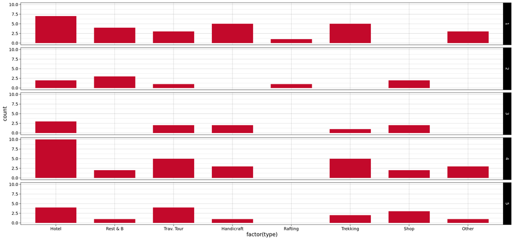

```r
ggplot(
  businesses_hhs,
  aes(x=factor(type))
  ) +
  geom_bar(
  stat="count",
  width=0.7,
  fill="#c3092b") +
  facet_grid(sub_grp ~ .) +
  scale_x_discrete(
  breaks=1:9,
  labels=c(
    "Hotel",
    "Rest & B",
    "Trav. Tour",
    "Handicraft",
    "Rafting",
    "Trekking",
    "Mountnring",
    "Shop",
    "Other"
    )
  ) +
  theme_linedraw()
```

# Viewing clusters on a map

```r
# Let's assign some names to these clusters
businesses_hhs <- businesses_hhs %>%
  mutate(
    cluster_name = ifelse(
      sub_grp == 1, "Worried abt everything",
      ifelse(
        sub_grp == 2, "Only worried about paying loans",
        ifelse(
          sub_grp == 3, "Worried about operating and getting customers",
          ifelse(
            sub_grp == 4, "Financially worried (loans, funds, taxes)",
            ifelse(
              sub_grp == 5, "Mixed/unclear",
              ifelse(
                sub_grp == 6, "Six", "Seven"
              )
            )
          )
        )
      )
    )
  )


# Cover lat/lng to numeric values and visualize
businesses_hhs$lat <-as.numeric(
  as.character(businesses_hhs$X_m_coodinates_latitude)
  )

businesses_hhs$lng <- as.numeric(
  as.character(    businesses_hhs$X_m_coodinates_longitude)
  )

onlyLatLng <- businesses_hhs[!is.na(businesses_hhs$lat), ]
onlyLatLng <- businesses_hhs[!is.na(businesses_hhs$lng), ]

colors <- c(
  "#e41a1cff",
  "#377eb8ff",
  "#4daf4aff",
  "#984ea3ff",
  "#ff7f00ff",
  "#ffff33ff",
  "#a65628ff"
  )
factpal <- colorFactor(colors, onlyLatLng$cluster_name)

leaflet(data = onlyLatLng, width = "70%") %>%
  addProviderTiles(providers$CartoDB.Positron) %>%
  addCircleMarkers(
    lng = ~lng,
    lat = ~lat,
    color = ~factpal(cluster_name),
    stroke = FALSE,
    fillOpacity = 0.5,
    label = ~name) %>%
  addLegend(
    "bottomright",
    pal = factpal,
    values = ~cluster_name,
    title = "Cluster Assignment",
    opacity = 1
  )
```

[interactive chart not shown]